# A Hierarchical Model of Non-homogeneous Poisson Processes for Twitter Retweets

2018-01-26 (Fri)

## #thehandmaidstale

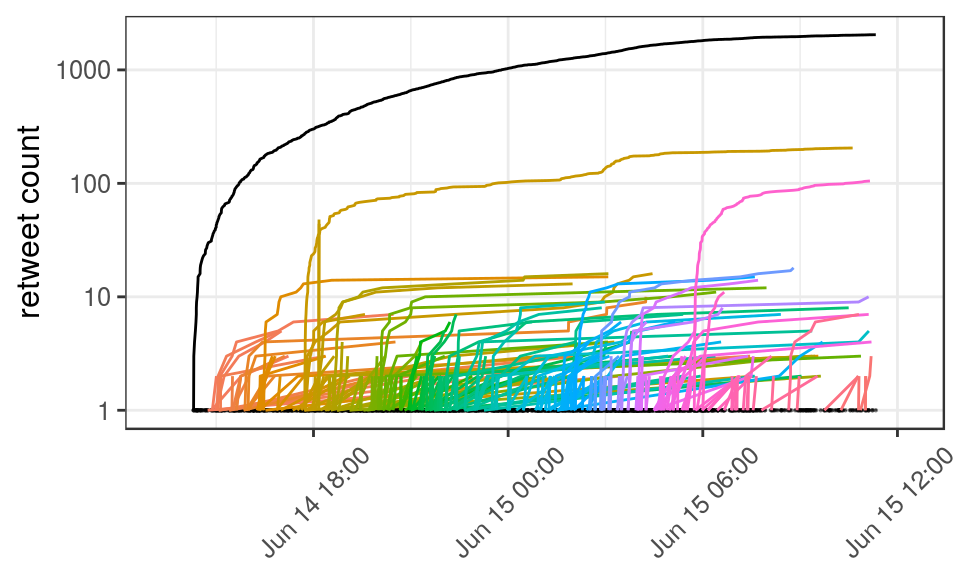

## Outline

1. Extend one kind of non-homogeneous Poisson process (NHPP) and apply to single sequences of event times:
   - **original tweets** of a hashtag
   - **retweets** of one original
2. Model **retweet count** vs **follower count** by censored regression
3. Model **retweets** of all originals by a hierarchical NHPP model
   - **follower count** as a covariate
4. Application

## The power law and hybrid processes

## NHPP (one-dimensional)

If a sequence of events is assumed to arise from an NHPP with intensity function \(h(t)\geq 0\)

- The random variable of the number of events within \([t_1,t_2]\) follows the Poisson distribution with mean \(\displaystyle\int_{t_1}^{t_2}h(t)dt\)
- Independent of the random number of events in any other disjoint interval
- Also define the cumulative intensity \(H(t)=\displaystyle\int_0^t h(t)dt\)

## Power law process

- \(h(t)=\gamma t^{-\lambda}\), where \(\gamma>0,\lambda<1\)
- Some call it Weibull process in reliability
- **N.B.** \(\neq\) a renewal process with power-law distributed interarrival times
- Common special case: homogeneous Poisson process
  - Power law process with \(\lambda=0\)
  - Renewal process with exponential distributed interarrival times

## Duane plot (Duane 1964)

How to check if the power law process is appropriate for the data?

- Let \(\{t_i,i=1,2,\ldots,n\}\) be a sequence of event times, \(0\leq t_1\leq t_2\leq\cdots\leq t_n\)
- Plot \(t_i/i\) vs \(t_i\) on log-log scale
- If the data is indeed generated from the power law process, the plot will give approximately a straight line with slope \(\lambda\)

## Duane plot

Why \(t_i/i\) vs \(t_i\) on log-log scale?

- Denote \(N(t)\) as the number of events in the interval \([0,t]\)
- Expectation \(\displaystyle E[N(t)]=H(t)=\int_0^t h(t)dt=\frac{\gamma t^{1-\lambda}}{1-\lambda}\)
- So \(t_i\) should be such that \[ \frac{\gamma t_i^{1-\lambda}}{1-\lambda}\approx i \quad\Leftrightarrow\quad \log\left(\frac{t_i}{i}\right)\approx\log\left(\frac{1-\lambda}{\gamma}\right)+\lambda\log t_i\]

## Sidetrack

How to check if some (non-temporal) data are Weibull distributed?

- Consider a sequence \(\{x_i,i=1,2,\ldots,n\}\) assumed to be iid
- Plot \(-\log\hat{S}(x_i)\) vs \(x_i\) on log-log scale, where \(\hat{S}(x_i)\) is the empirical survival function
- If \(\{x_i\}\) indeed comes from the Weibull distribution, the plot will give approximately a straight line with slope equal to the shape parameter

## Duane plot for #thehandmaidstale

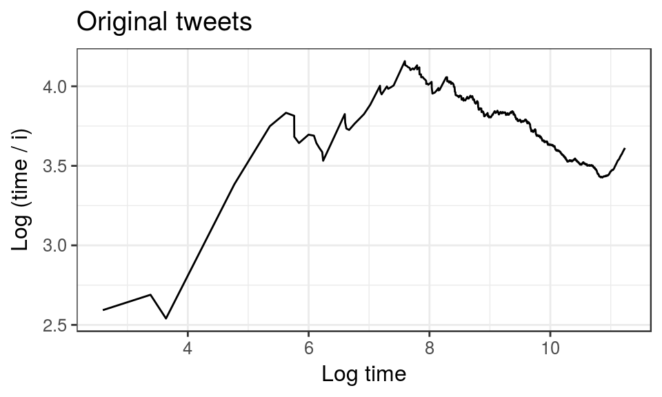

## Duane plot for #thehandmaidstale

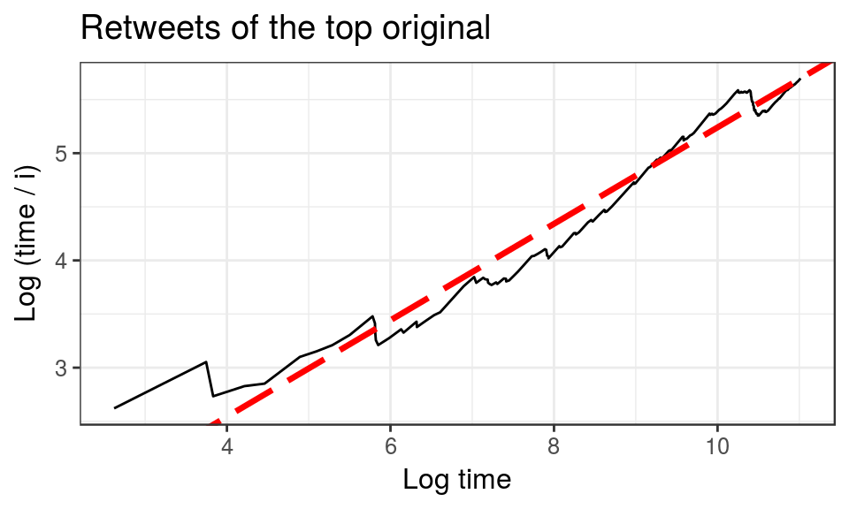

## Extending the power law process

- Latter events seem to occur at a rate slower than expected by the power law process
- We call an NHPP with \(h(t)=\gamma t^{-\lambda}e^{-\theta t}\) the **hybrid process**, where \(\gamma>0,\lambda<1,\theta\geq0\)
- Alternatively called "power law with exponential cutoff" (Mathews et al. 2017)
- When \(\theta=0\), the hybrid process becomes the power law process

## Fitting the hybrid process

- Data: retweets of **top** original only
- Inference: maximum likelihood
- Estimates: \(\left(\hat{\lambda},\hat{\theta},\hat{\gamma}\right)=(0.45,0,0.261)\)
- Including \(\theta\) doesn't improve the fit here

## Going back to the whole data set

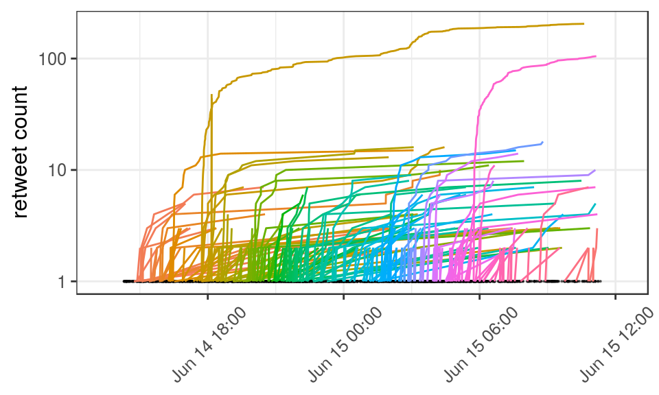

## Fitting the hybrid process (cont'd)

- Data: retweets of **all** originals
- Hierarchical approach: a distribution to govern the parameter values for retweets of each original
- Question: can we actually explain the distribution of the parameters (and that of the retweet count) by some covariates?

## Censored regression

## Terminology

For \(i\)-th original, where \(i=1,2,\ldots,n\)

[output not shown]

## Exploratory analysis

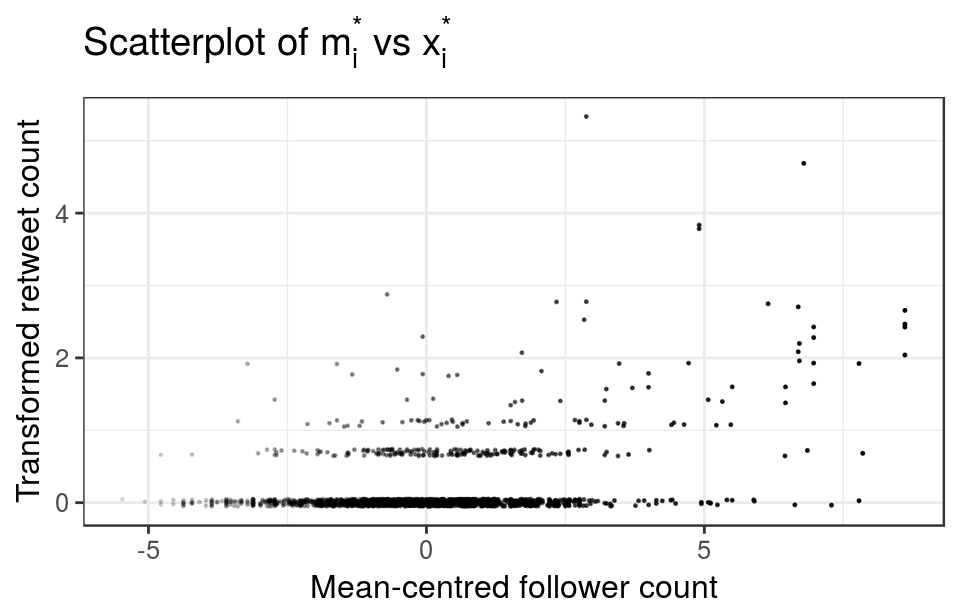

## Model

- Censored regression (Tobin 1958) \[ m_i^{*}=\max(0,\alpha+\beta x_i^{*}+\epsilon_i) \] \[ \epsilon_i~\overset{\text{iid}}{\sim}~\text{N}(0,\tau^{-1}) \]
- Note the difference with \[ m_i^{*}=\max(0,\alpha+\beta x_i^{*})+\epsilon_i \]
- \(x_i^{*}\) orthogonalises \(\alpha\) and \(\beta\) in inference

## Extending the original censored regression

- Terms with higher powers of \(x_i^{*}\) can be added to potentially improve fit
- Linear and quadratic fits give maximum log-likelihood of 828.4 and 841.47, respectively
- Therefore, the following censored regression will be used in the hierarchical model: \[ m_i^{*}=\max\left(0,\alpha+\beta x_i^{*}+\kappa\left(x_i^{*}\right)^2+\epsilon_i\right) \]

## Graphical fit

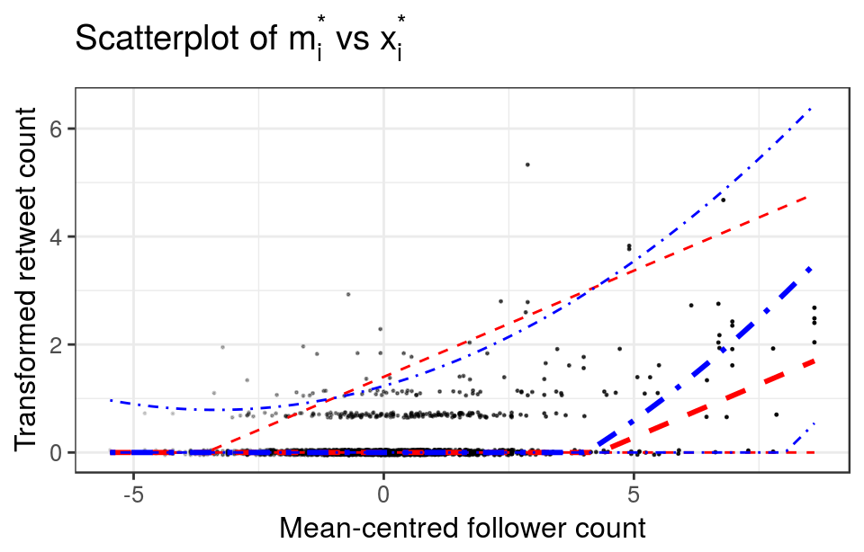

## Hierarchical model for all retweets

## Recall

- \(h(t)=\gamma t^{-\lambda}e^{-\theta t}, H(t)=\gamma\Gamma(1-\lambda,\theta t)\theta^{\lambda-1}\)
  - \(\Gamma(.,.)\) is the incomplete Gamma function
- \(h(t)\) and \(H(t)\) increase linearly with \(\gamma\)
- \(\gamma\) can be seen as a proxy for the retweet count
- Making \(\gamma\) depend on (mean-centred) follower count removes the need to model (transformed) retweet count separately

## Complete model specification

- The \(i\)-th original occurs at time \(t_i\)
- Its \(m_i\) retweets follow a hybrid process with intensity \[ h_i(t)=\gamma_i(t-t_i)^{-\lambda}e^{-\theta(t-t_i)}, t\geq t_i \]
- Location shift from \(t\) to \(t-t_i\): retweets occur relative to the creation of the \(i\)-th original
- Relationship of \(\gamma_i\) and \(x_i^{*}\) (mean-centred follower count): \[ \log(1+\gamma_i) = \max\left(0,\alpha+\beta x_i^{*}+\kappa\left(x_i^{*}\right)^2+\epsilon_i\right) \]
- As before, \(\epsilon_i~\overset{\text{iid}}{\sim}~\text{N}(0,\tau^{-1})\)

## All notations

- Scalars
  - Observation period: \(T~\left(\geq t_n\geq t_{n-1}\geq\cdots\geq t_1\geq0\right)\)
  - Parameters: \(\alpha,\beta,\kappa,\lambda,\tau,\theta\)
- For each original
  - \(i\)-th original's & its retweets' times: \(\boldsymbol{t}_i=(t_i,t_{i1},t_{i2},\ldots,t_{im_i})\)
  - \(\gamma_i\) not a parameter but a function of \(\alpha,\beta,\kappa,\epsilon_i\) and \(x_i^{*}\)
- Vectors of length \(n\)
  - Retweet counts: \(\boldsymbol{m}=(m_1,m_2,\ldots,m_n)\)
  - All event times: \(\boldsymbol{t}=\{\boldsymbol{t}_1,\boldsymbol{t}_2,\ldots,\boldsymbol{t}_n\}\)
  - (Mean-centred) follower counts: \(\boldsymbol{x}^{*}=(x_1^{*},x_2^{*},\ldots,x_n^{*})\)
  - Random errors / latent variables: \(\boldsymbol{\epsilon}=(\epsilon_1,\epsilon_2,\ldots,\epsilon_n)\)

## Likelihood

\[ f(\boldsymbol{m},\boldsymbol{t}|\boldsymbol{x}^{*},\alpha,\beta,\kappa,\lambda,\tau,\boldsymbol{\epsilon},\theta=0) = \prod_{i:m_i>0}\left[\boldsymbol{1}_{\{\gamma_i>0\}}\gamma_i^{m_i}\prod_{j=1}^{m_i}(t_{ij}-t_{i})^{-\lambda}\right] \] \[ \times\exp\left(-\left(1-\lambda\right)^{-1}\sum_{i=1}^{n}\gamma_i(T-t_i)^{1-\lambda}\right) \] \[ f(\boldsymbol{m},\boldsymbol{t}|\boldsymbol{x}^{*},\alpha,\beta,\kappa,\lambda,\tau,\boldsymbol{\epsilon},\theta>0) = \prod_{i:m_i>0}\left[\boldsymbol{1}_{\{\gamma_i>0\}}\gamma_i^{m_i}\prod_{j=1}^{m_i}(t_{ij}-t_{i})^{-\lambda}\right] \] \[ \times\exp\left(-\theta^{\lambda-1}\sum_{i=1}^{n}\left[\gamma_i\Gamma(1-\lambda,\theta(T-t_i))\right] - \theta\sum_{i:m_i>0}\sum_{j=1}^{m_i}(t_{ij}-t_{i})\right)\]

## \(\theta=0\) vs \(\theta>0\)

- We are actually interested which one is adequate
  - Hierarchical model of power law processes \((\theta=0)\)
  - Hierarchical model of hybrid processes \((\theta>0)\)
- Treat them as two different models
  - \(f(\boldsymbol{m},\boldsymbol{t}|\boldsymbol{x}^{*},\alpha,\beta,\kappa,\lambda,\tau,\boldsymbol{\epsilon},\theta=0) \rightarrow f(\boldsymbol{m},\boldsymbol{t}|\boldsymbol{x}^{*},\boldsymbol{\eta}_0,M=0)\), where \(\boldsymbol{\eta}_0=(\alpha,\beta,\kappa,\lambda,\tau,\boldsymbol{\epsilon})\)
  - \(f(\boldsymbol{m},\boldsymbol{t}|\boldsymbol{x}^{*},\alpha,\beta,\kappa,\lambda,\tau,\boldsymbol{\epsilon},\theta>0) \rightarrow f(\boldsymbol{m},\boldsymbol{t}|\boldsymbol{x}^{*},\boldsymbol{\eta}_1,M=1)\), where \(\boldsymbol{\eta}_1=(\alpha,\beta,\kappa,\lambda,\tau,\boldsymbol{\epsilon},\theta)\)
- Infer \(M\) via model selection in inference

## Inference

Bayesian approach because of:

- The presence of latent variables \(\boldsymbol{\epsilon}\)
- Model selection required between \(M=0\) and \(M=1\)

Independent priors: \[ \alpha,\beta,\kappa\sim\text{N}(\text{mean}=0,~\text{sd}=100) \] \[ \tau,1-\lambda\sim\text{Gamma}(\text{shape}=1,~\text{rate}=0.001) \] \[ (\text{For}~M=1)~\theta\sim\text{Gamma}(\text{shape}=1,~\text{rate}=0.001) \] \[ M: \pi(M=0) = 1 - \pi(M=1) \]

## MCMC (individual models)

Metropolis-within-Gibbs (MWG) algorithm

- Update each scalar parameter individually
- Metropolis steps:
  - \(\alpha,\beta,\kappa,\lambda\)
  - \(\epsilon_i, i = 1,2,\ldots,n\)
  - (For \(M=1\)) \(\theta\)
- Gibbs step: \(\tau\)

## MCMC (model selection)

Gibbs variable selection (Dellaportas, Forster, and Ntzoufras 2002)

Required quantities

1. Likelihoods: \(f(\boldsymbol{m},\boldsymbol{t}|\boldsymbol{x}^{*},\boldsymbol{\eta}_0,M=0)\) & \(f(\boldsymbol{m},\boldsymbol{t}|\boldsymbol{x}^{*},\boldsymbol{\eta}_1,M=1)\)
2. Model priors: \(\pi(M=0)\) & \(\pi(M=1)\)
3. Prior of \(\theta\) under \(M=1\): \(\pi(\theta|M=1)\)
4. Pseudoprior of \(\theta\) under \(M=0\): \(\pi(\theta|M=0)\)

## MCMC (model selection)

If current value of \(M=1\):

1. Draw \(\boldsymbol{\eta}_1\) using the individual MWG algorithm (previous slide)
2. Split \(\boldsymbol{\eta}_1\) into \(\boldsymbol{\eta}_0\) and \(\theta\) \(\quad\Leftrightarrow\quad\boldsymbol{\eta}_1=(\boldsymbol{\eta}_0,\theta)\)
3. Calculate \(A_0\) and \(A_1\):
   - \(A_0 = f(\boldsymbol{m},\boldsymbol{t}|\boldsymbol{x}^{*},\boldsymbol{\eta}_0,M=0)\pi(\theta|M=0)\pi(M=0)\)
   - \(A_1 = f(\boldsymbol{m},\boldsymbol{t}|\boldsymbol{x}^{*},\boldsymbol{\eta}_1,M=1)\pi(\theta|M=1)\pi(M=1)\)
4. Set \(M\) to \(0\) with prob. \(\displaystyle\frac{A_0}{A_0+A_1}\) or \(1\) with prob. \(\displaystyle\frac{A_1}{A_0+A_1}\)

## MCMC (model selection)

If current value of \(M=0\):

1. Draw \(\boldsymbol{\eta}_0\) using the individual MWG algorithm
2. Draw \(\theta\) from pseudoprior \(\pi(\theta|M=0)\)
3. Combine \(\boldsymbol{\eta}_0\) and \(\theta\) to form \(\boldsymbol{\eta}_1\) \(\quad\Leftrightarrow\quad\boldsymbol{\eta}_1=(\boldsymbol{\eta}_0,\theta)\)
4. Calculate \(A_0\) and \(A_1\) as before
5. Set \(M\) to \(0\) or \(1\) with probabilities as before

## Bayes factor

- The empirical proportion of \(M=1\) in the converged chain is the estimate for the posterior probability \(\pi(M=1|\boldsymbol{m},\boldsymbol{t},\boldsymbol{x}^{*})\)
- Similarly for \(\pi(M=0|\boldsymbol{m},\boldsymbol{t},\boldsymbol{x}^{*})\)
- Bayes factor for model \(1\) over model \(0\) is \[ B_{10}=\frac {\hat{\pi}(M=1|\boldsymbol{m},\boldsymbol{t},\boldsymbol{x}^{*})} {\hat{\pi}(M=0|\boldsymbol{m},\boldsymbol{t},\boldsymbol{x}^{*})} \left/\frac {\pi(M=1)} {\pi(M=0)} \right. \]

## Application

## #thehandmaidstale

Season 1 finale, 2017-06-14

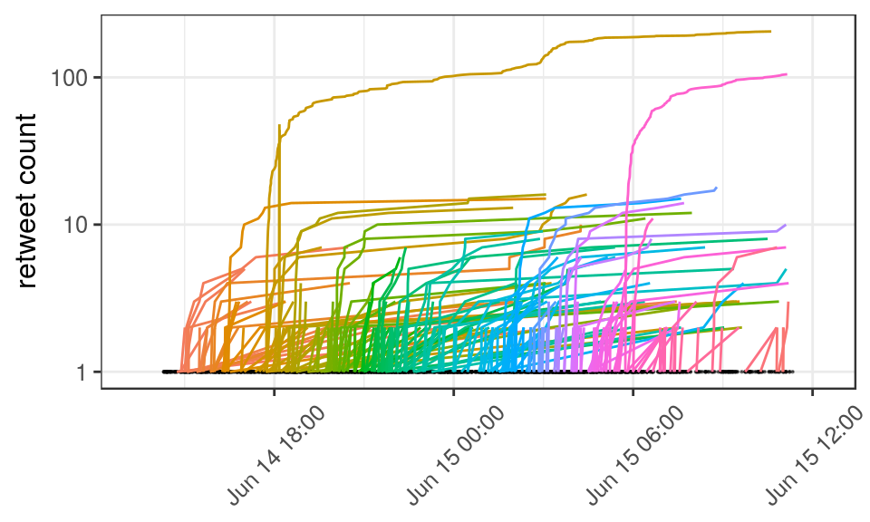

## #thehandmaidstale

- Observation period: \(T\approx21\) hours
- Originals: \(n=2043\), of which \(265\) were ever retweeted
- Retweets: \(\displaystyle\sum_{i=1}^nm_i=971,~\underset{1\leq i\leq n}{\max}m_i=204\)

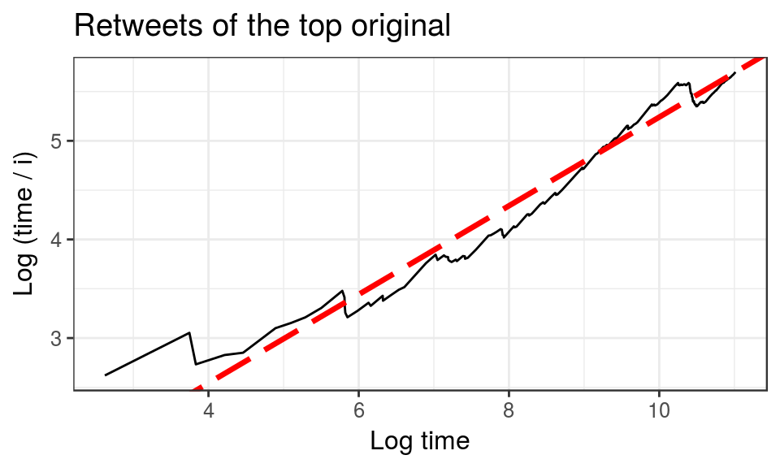

## #gots7

Season 7 premiere, 2017-07-16

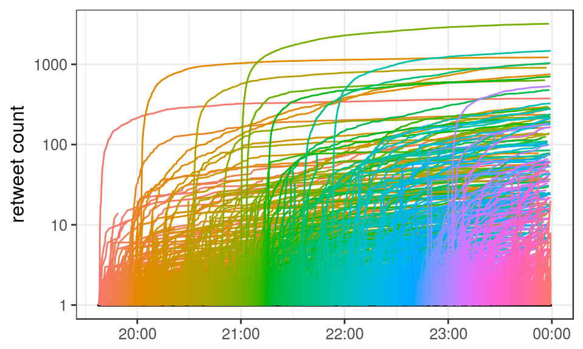

## #gots7

- Observation period: \(T\approx4.4\) hours
- Originals: \(n=25420\), of which \(3145\) were ever retweeted
- Retweets: \(\displaystyle\sum_{i=1}^nm_i=29751,~\underset{1\leq i\leq n}{\max}m_i=3204\)

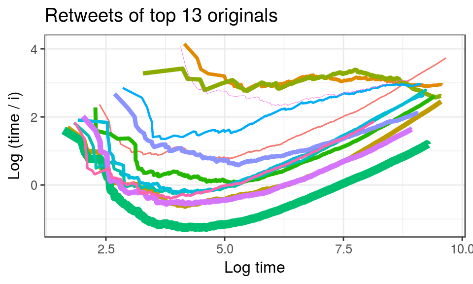

## Posterior density

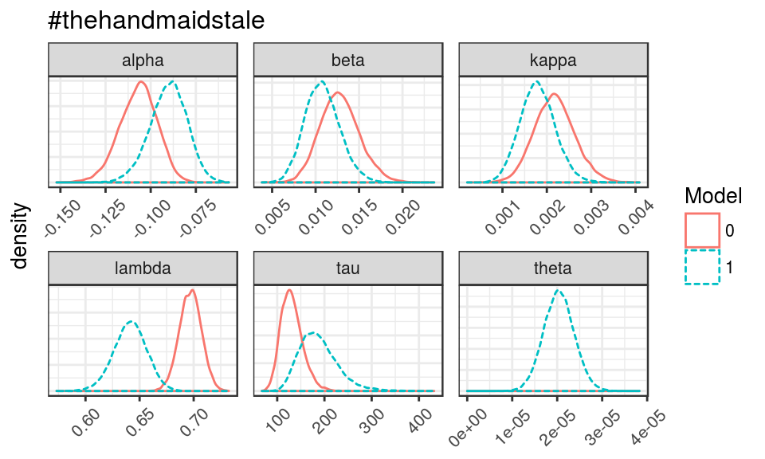

## Posterior density

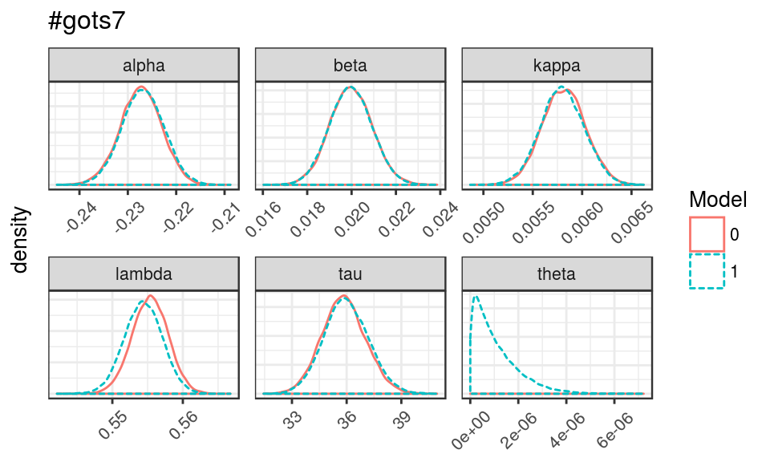

## Bayes factor & model selection

#thehandmaidstale

- \(B_{10}=6.572\)
  - Hierarchical model of hybrid processes selected
- Mathews et al. (2017): "exponential cutoff" phenomenon for tweets collected over a similar duration of 24 hours

#gots7

- \(B_{10}=1.219\times 10^{-9}\)
  - Hierarchical model of power law processes selected
- Mathews et al. (2017): power law phenomenon for tweets collected over a similar duration of 3 hours

## Prediction

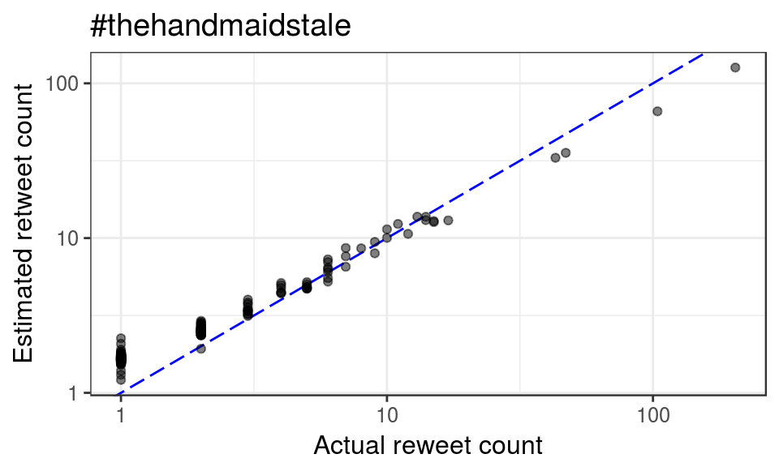

## Prediction

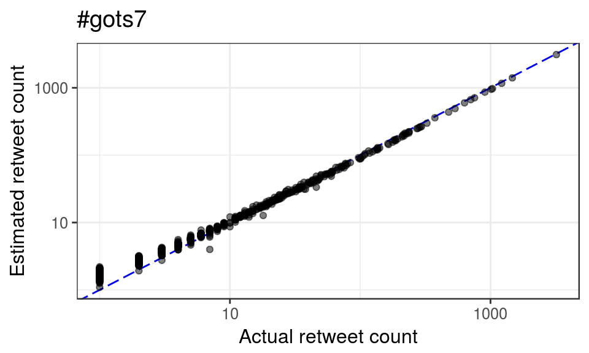

## Summary

- Use Duane plot as a diagnostic for the power law process, which is extended to the hybrid process
- Model relationship between follower count and retweet count using censored regression
- Construct a hierarchical model for retweets by combining the hybrid process and censored regression
- Infer the model choice between power law and hybrid processes in MCMC algorithm
- Selected models for different data consistent with previous findings

## Bibliography

Dellaportas, Petros, Jonathan J Forster, and Ioannis Ntzoufras. 2002. “On Bayesian Model and Variable Selection Using MCMC.” *Statistics and Computing* 12: 27–36.

Duane, J. T. 1964. “Learning Curve Approach to Reliability Monitoring.” *IEEE Transactions on Aerospace* 2 (2): 563–66.

Mathews, Peter, Lewis Mitchell, Giang Nguyen, and Nigel Bean. 2017. “The Nature and Origin of Heavy Tails in Retweet Activity.” In *Proceedings of the 26th International Conference on World Wide Web Companion*, 1493–8. WWW ’17 Companion. Republic; Canton of Geneva, Switzerland: International World Wide Web Conferences Steering Committee. doi:10.1145/3041021.3053903.

Tobin, James. 1958. “Estimation of Relationships for Limited Dependent Variables.” *Econometrica* 26 (1): 24–36. doi:10.2307/1907382.